# DiversityTutorial

## Rarefaction

The problem is that we have taken no account of differing sample size which will impact the observed diversity. We can demonstrate this by generating rarefaction curves. We will only do this for ten samples into total. Selecting 5 CD and 5 healthy individuals at random:

```r
set.seed(42)
meta_CD5 <- meta_CDH[sample(which(meta_CDH$Type == "CD"), 5), ]
meta_H5 <- meta_CDH[sample(which(meta_CDH$Type == "H"), 5), ]
meta_CDH10 <- rbind(meta_CD5,meta_H5)
otus_CDH10 <- otus[rownames(meta_CDH10),]
```

Then we define a new function of our own ‘rarefySamples’:

```r
rarefySamples <- function(otus, stepR){

smax <- max(rowSums(otus))

rsamples <- seq(10, smax, by=stepR)

sizes <- rowSums(otus)
names <- rownames(otus)

snames <- character(0)
diversities <- integer(0)
ssizes <- integer(0)

rare.df <- data.frame(name= character(0), size= integer(0), spec_number = integer(0))
#loop sample sizes
for (rsample in rsamples){
    #rarefy
    rare <- rarefy(otus, rsample, se = FALSE, MARGIN = 1)
    #loop samples
    i = 1
    for (size in sizes){
        if (rsample < size){
            snames <- c(snames, names[i])
            diversities <- c(diversities,rare[[i]])
            ssizes <- c(ssizes,rsample)
        }
        i = i + 1
    }
}

rare.df <- data.frame(Names=snames,Sizes=ssizes,Diversities=diversities)

return(rare.df)
}
```

Alternatively you can read this function direct from an R file in the DiversityTutorial directory:

```r
source("RarefySamples.R")
```

and run it on the subsetted data:

```r
rarefy.df <- rarefySamples(otus_CDH10,100)
```

We now want to add type labels to this dataframe, there are probably more elegant ways to do this…

```r
names <- rarefy.df$Names
NSamples <- length(names)
types <- rep("CD", times = NSamples)
types <- factor(types)
levels(types) <- c("CD","H")
i <- 1
for(name in names){
  types[[i]] <- meta_CDH[name,]$Type
  i <- i + 1
}
rarefy.df$Types <- types
```

Now we plot the rarefaction curves:

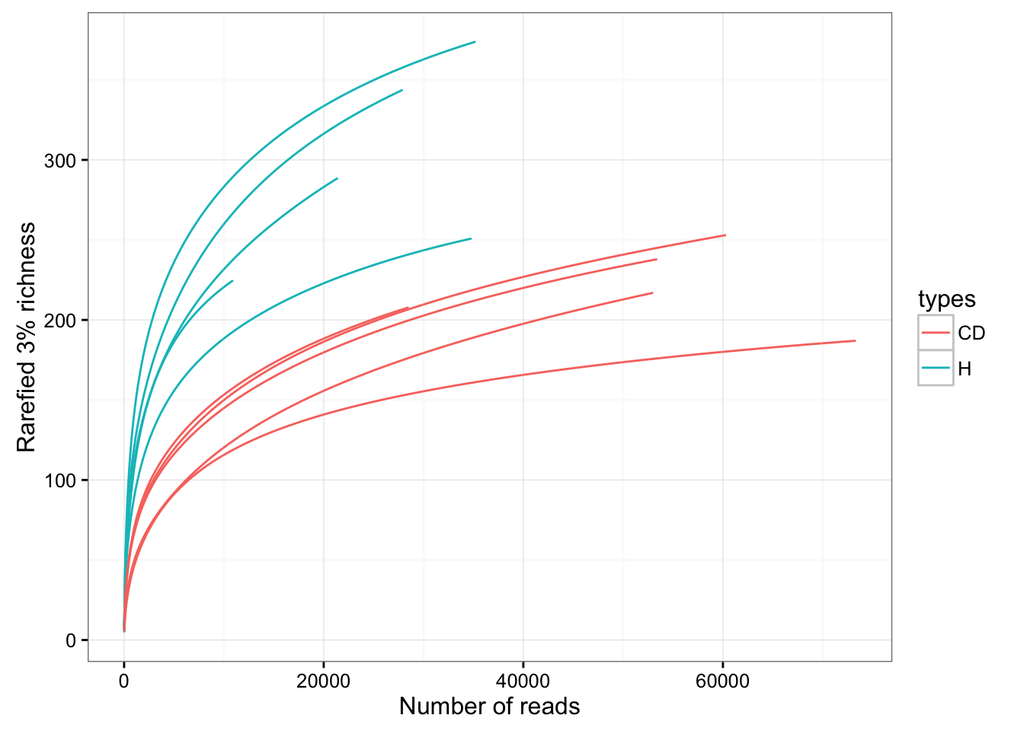

```r
p <- ggplot(data=rarefy.df,aes(x=Sizes,y=Diversities,shape=Names,colour=types)) + theme_bw() + geom_line() + ylab("Rarefied 3% richness") + xlab("Number of reads")
plot(p)
```

This illustrates that we need to correct for sample size. First we filter all samples with less than 10,000 reads and then rarefy species richness to 10,000:

```r
otus_CDH_1e4 <- otus_CDH[rowSums(otus_CDH)>1e4,]
meta_CDH_1e4 <- meta_CDH[rownames(otus_CDH_1e4),]
meta_CDH_1e4$S_rare <- rarefy(otus_CDH_1e4, 10000, se = FALSE, MARGIN = 1)
```

The comparison of richness between Crohn’s and healthy children is now much more significant:

```r
t.test(S_rare ~ Type,data=meta_CDH_1e4)
```

```
##
##  Welch Two Sample t-test
##
## data:  S_rare by Type
## t = -5.2163, df = 32.386, p-value = 1.025e-05
## alternative hypothesis: true difference in means is not equal to 0
## 95 percent confidence interval:
##  -88.19349 -38.67487
## sample estimates:
## mean in group CD  mean in group H
##         158.1278         221.5620
```

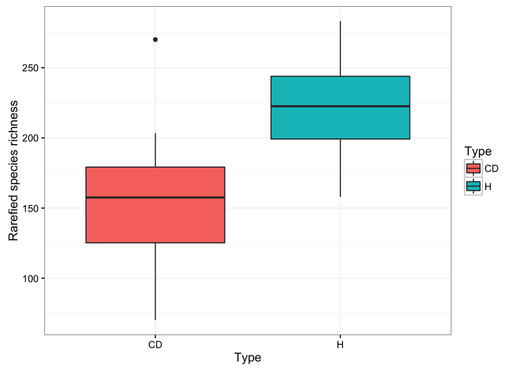

```r
p <- ggplot(meta_CDH_1e4, aes(x=Type, y=S_rare, fill=Type)) + geom_boxplot() + theme_bw() + ylab("Rarefied species richness")
plot(p)
```

## Shannon Index

What about an alternative diversity index? We will calculate Shannon’s diversity but first we need to subsample our otu table. We therefore start by generating a subsampled otu matrix of 10,000 reads using the vegan rrarefy function:

```r
otus_CDH_1e4R <- rrarefy(otus_CDH_1e4, 10000)
```

We then use the vegan diversity function to calculate Shannon’s entropy on the subsampled matrix. Does anyone remember why I have added the exp() function here?

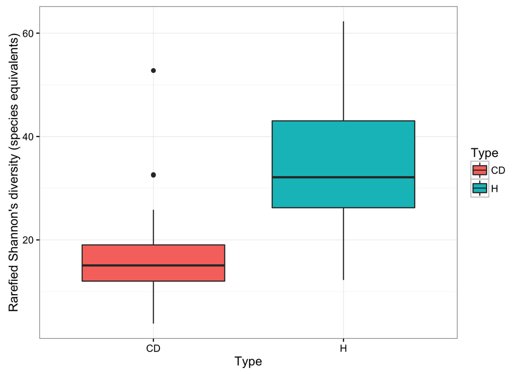

```r
meta_CDH_1e4$Sh <- exp(diversity(otus_CDH_1e4R, index = "shannon", MARGIN = 1, base = exp(1)))
p <- ggplot(meta_CDH_1e4, aes(x=Type, y=Sh, fill=Type)) + geom_boxplot() + theme_bw() + ylab("Rarefied Shannon's diversity (species equivalents)")
plot(p)
```

```r
t.test(Sh ~ Type,data=meta_CDH_1e4)
```

```
##
##  Welch Two Sample t-test
##
## data:  Sh by Type
## t = -3.6778, df = 36.159, p-value = 0.0007596
## alternative hypothesis: true difference in means is not equal to 0
## 95 percent confidence interval:
##  -22.932268  -6.631995
## sample estimates:
## mean in group CD  mean in group H
##         18.36540         33.14753
```

## Evenness

This is now less significant than for richness. What does that tell us about the evenness of the Crohn’s and healthy individuals. Lets test that with Peilou’s index of evenness:

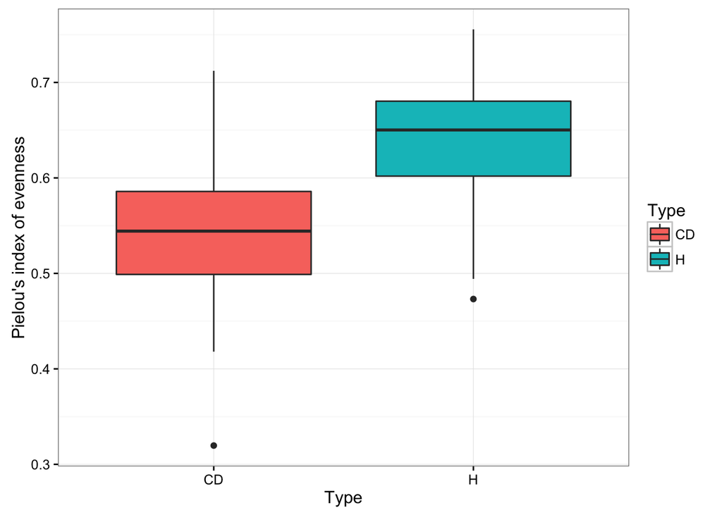

```r
meta_CDH_1e4$P <- diversity(otus_CDH_1e4R, index = "shannon", MARGIN = 1, base = exp(1))/log(specnumber(otus_CDH_1e4R))
p <- ggplot(meta_CDH_1e4, aes(x=Type, y=P, fill=Type)) + geom_boxplot() + theme_bw() + ylab("Pielou's index of evenness")
plot(p)
```

```r
t.test(P ~ Type,data=meta_CDH_1e4)
```

```
##
##  Welch Two Sample t-test
##
## data:  P by Type
## t = -3.2377, df = 35.5, p-value = 0.002614
## alternative hypothesis: true difference in means is not equal to 0
## 95 percent confidence interval:
##  -0.1443766 -0.0331305
## sample estimates:
## mean in group CD  mean in group H
##        0.5424874        0.6312409
```

## Phylogenetic Diversity

We will now have a look at the phylogenetic diversity, first we read in an unrooted tree generated from mafft followed by fasttree and plot using phyloseq:

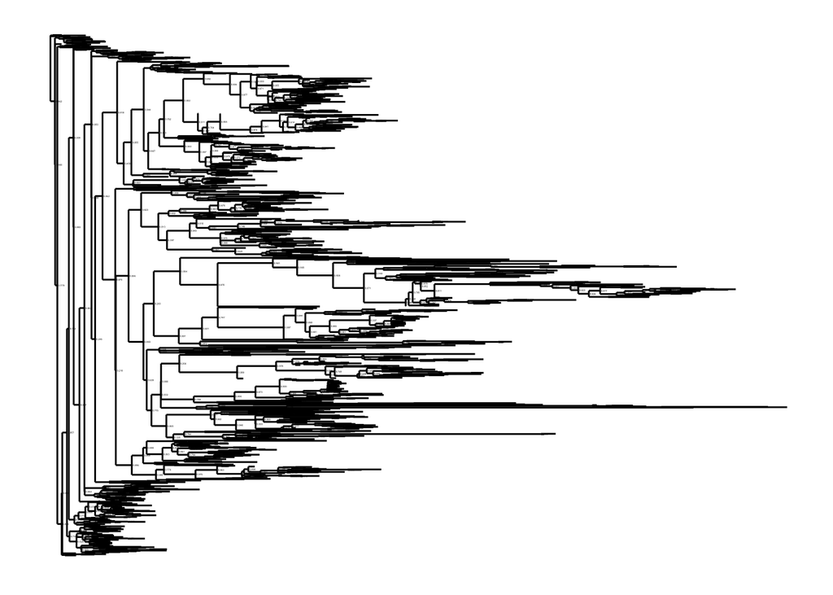

```r
otus_tree <- read.tree("otus.tree")
plot_tree(otus_tree)
```

Phylogenetic diversity is influenced by sample size just like any other metric. We therefore use the subsampled data sets from above. We calculate phylogenetic diversity using the picante package function pd. We are using weighted phylogentic diversity so we first calculate proportions:

```r
otus_CDH_1e4RP <- otus_CDH_1e4R/rowSums(otus_CDH_1e4R)
pd.results <- pd(otus_CDH_1e4RP, otus_tree, include.root = FALSE)
meta_CDH_1e4$PD <- pd.results$PD
```

Plot and calculate significance as usual:

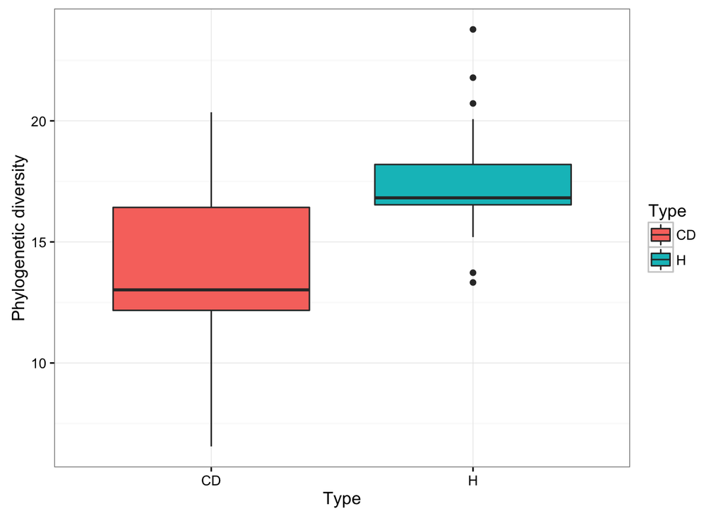

```r
p <- ggplot(meta_CDH_1e4, aes(x=Type, y=PD, fill=Type)) + geom_boxplot() + theme_bw() + ylab("Phylogenetic diversity")
plot(p)
```

```r
t.test(PD ~ Type,data=meta_CDH_1e4)
```

```
##
##  Welch Two Sample t-test
##
## data:  PD by Type
## t = -3.9564, df = 34.397, p-value = 0.0003616
## alternative hypothesis: true difference in means is not equal to 0
## 95 percent confidence interval:
##  -5.515555 -1.773217
## sample estimates:
## mean in group CD  mean in group H
##         13.86859         17.51298
```

## Diversity Across Multiple Groups

We are now going to look at the effect of EEN on diversity in the children with Crohn’s disease. The factor variable Sample denotes at what stage of treatment the sample was taken (A < 6 days EEN, B: ~16 & C: ~32 days, D ~ 54days). A final sample E was collected when patients returned to their habitual diet (E:~63 days after EEN cessation). In some cases two samples at E were taken we are going to relabel the second sample and we will also use the Sample variable to encode the healthy controls

```r
meta$Sample[meta$Sample == 'E2 (second sample after EEN)'] <- 'E'
levels(meta$Sample) <- c(levels(meta$Sample), "H")
meta[meta$Type=="H",]$Sample <- "H"
```

Then we filter for samples with less than 10,000 reads. Rarefy to 10,000 reads and calcualte species richness. Finally we performed a Kruskal-Wallis test to determine if Sample significantly impacts rarefied richness:

```r
otus_1e4 <- otus[rowSums(otus)>10000,]
meta_1e4 <- meta[rownames(otus_1e4),]
meta_1e4$S_rare <- rarefy(otus_1e4, 10000, se = FALSE, MARGIN = 1)
kruskal.test(meta_1e4$S_rare  ~ Sample, data=meta_1e4)
```

```
##
##  Kruskal-Wallis rank sum test
##
## data:  meta_1e4$S_rare by Sample
## Kruskal-Wallis chi-squared = 57.216, df = 5, p-value = 4.565e-11
```

Having determined that Sample is significant we plot the richness at each Sample point:

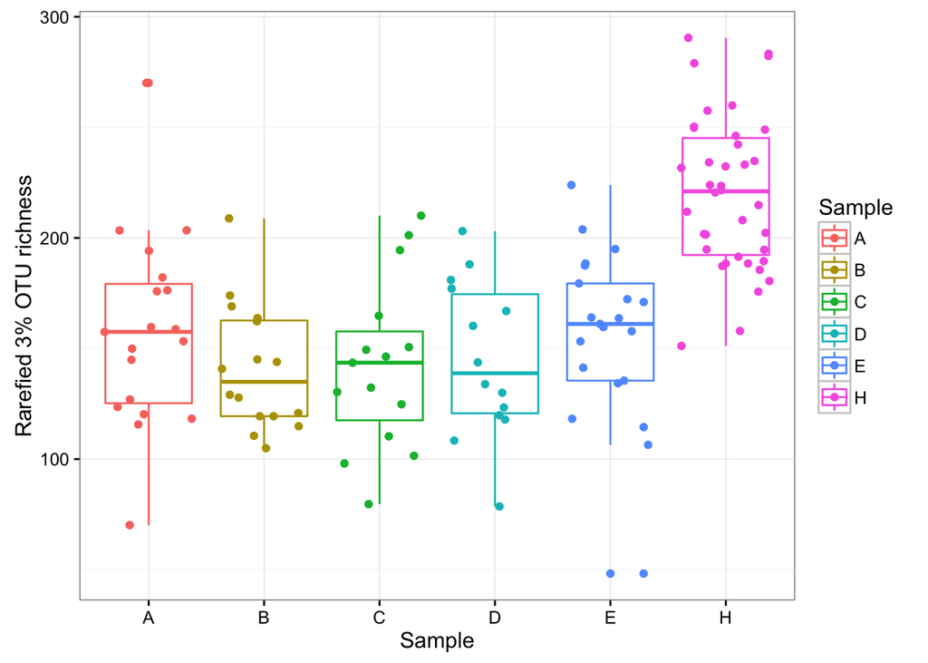

```r
p <- qplot(data=meta_1e4,Sample,S_rare,colour=Sample,geom=c("boxplot","jitter")) + ylab("Rarefied 3% OTU richness") + theme_bw()
plot(p)
```

We see that treatment is associated with a reduction in diversity which recovers when EEN treatment ceases. However, individuals are different and it makes sense to look at trajectories of diversity for each Subject during treatment onnly. We can do that quite easilly with ggplot2. First we select just the CD samples and only during the treatment i.e. Samples A to D. We have to manipulate some of the data variables too, just to make sure we only have samples from subjects still on EEN:

```r
meta_EEN <- subset(meta_1e4,meta_1e4$Type == "CD" & meta_1e4$Sample != "E")
meta_EEN[is.na(meta_EEN$daysEENstop),]$daysEENstop <- -1
meta_EEN$daysEENstart <- as.numeric(meta_EEN$daysEENstart)
selC <- (complete.cases(meta_EEN$daysEENstart) &  meta_EEN$daysEENstart) < 300 & as.numeric(meta_EEN$daysEENstop) < 3
meta_EEN <- subset(meta_EEN,selC)
```

We will finish with something more complex to illustate the power of ggplot visualisations and to understand better the impact of EEN on the microbial community diversity. We restructure data so that subjects are correctly ordered:

```r
MetaSE <- data.frame();
for(i in seq_along(levels(meta_EEN$Subject))){
    sub <- levels(meta_EEN$Subject)[i]
    MetaS <- subset(meta_EEN,meta_EEN$Subject == sub)
    MetaS <- MetaS[order(MetaS$Sample),]
    if(nrow(MetaS) >= 2){
        MetaSE <- rbind(MetaSE,MetaS)
    }
}
```

Then we plot subjects individually:

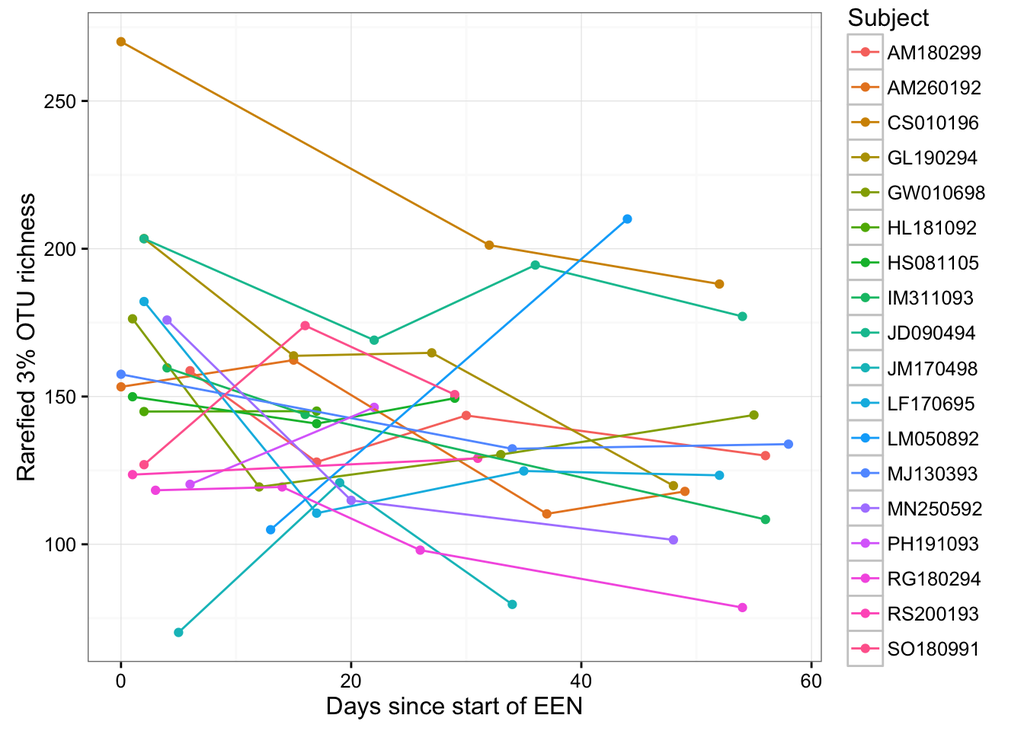

```r
colours <- c("#F0A3FF", "#0075DC", "#993F00","#4C005C","#2BCE48","#FFCC99","#808080","#94FFB5","#8F7C00","#9DCC00","#C20088","#003380","#FFA405","#FFA8BB","#426600")

qplot(data=MetaSE,daysEENstart,S_rare,colour=Subject) + geom_line() + ylab("Rarefied 3% OTU richness") + xlab("Days since start of EEN") + scale_fill_manual(values=colours) + theme_bw()
```